# turismo2

## Testes de hipótese

Os testes utilizados serão para a diferença de médias de duas amostras independentes. Ambas as hipóteses utilizaram o método bootstrap.

### Definição bootstrap

Bootstrap é um metodo feito para estimar a distribuição de um estimador ou teste estatístico através da reamostragem dos dados. Ele tratam os dados partindo do princípio de que eles vinheram da mesma população, com o proposito de avaliar a distribuição de interesse. Sobre condições normais e regulares, o bootstrap calcula uma aproximação para a distribuição de um estimador ou teste estatístico. O número de reamostragens possíveis com uma amostra de tamanho é $n$ é dado por $n^n$, como a reamostragem é feito com substituição, apenas parte dessas amostras serão únicas, o que é dado por $\begin{pmatrix} 2n - 1\\ n \end{pmatrix}$. Desta forma, como $n^n$ é uma quantidade muito grande mesmo para computadores com poder de computação considerável, o método Monte Carlo é utilizado, esse método calcula um estimador para a distribuição bootstrap a partir de parte dessa reamostragem. Por exemplo, caso o objetivo fosse estimar uma função de distribuição acumulada teriamos:

$$\overline F(t) \implies \hat F_n(t) \implies F_n(t)$$

$\overline F(t)$ é o estimador Monte Carlo, $\hat F_n(t)$ é o estimador bootstrap e $F_n(t)$ a distribuição de interesse. Outro conceito importante é o de convergência uniforme que é o cálculo de quão proximo a função do estimador está da função da distribuição de interesse. Para $\overline F(t) \implies \hat F_n(t)$, $B$ (número de reamostragens) precisar ser grande o suficiente para a convergência uniforme. Já para $\hat F_n(t) \implies F_n(t)$ é necessário converter as distribuições em distribuições limites $L$ que medem o comportamento assintótico (o que acontece com os objetos estatísticos quando aumentamos o tamanho). Assim, quando $\hat F_n(t)$ e $\implies F_n(t)$ tem seu número de elementos grandes o suficiente, teremos $\hat L \implies L$. Esses limites frequentemente vem de distribuições normais, ou seja, se o parâmetro de ambas as distribuições convergirem, então os limites também irão ter a convergência uniforme. Isso é a mesma coisa de dizer que os limites convergem quando o número de elementos é grande o suficiente. Por fim, se $\hat L \implies L$ converge, teremos a mesma situação para $\hat F_n(t) \implies F_n(t)$.

### Teste de hipótese para os meses de verão

O primeiro teste será das médias de crescimento em log das duas regiões nos meses de verão.

**Hipótese:** $$ H_0: \mu_N = \mu_S \\ H_\alpha: \mu_N > \mu_S\\ $$ Em que $\mu_N$ é a média populacional da região Nordeste e $\mu_S$ é a da região Sul.

**Coleta de dados:**

```python
media_nord = np.mean(log_nord_verao)
media_nord
```

```
-0.05918568206302657
```

```python
desvio_nord = np.std(log_nord_verao)
desvio_nord
```

```
0.9538062596588723
```

```python
media_sul = np.mean(log_sul_verao)
media_sul
```

```
0.3733397514430343
```

```python
desvio_sul = np.std(log_sul_verao)
desvio_sul
```

```
1.0209864509542639
```

**Normalidade dos dados:**

O teste que será utilizado é o de Shapiro Wilk. Para $p-value$ < $\alpha$ a hipótese nula é rejeitada e, portanto, a amostra não segue uma distribuição normal.

```python
#Considerando que o nível de significância é de 5%
alpha = 0.05
estatistica, p_valor = shapiro(log_nord_verao)
p_valor
```

```
5.025411610404262e-06
```

```python
estatistica, p_valor = shapiro(log_sul_verao)
p_valor
```

```
0.07041042298078537
```

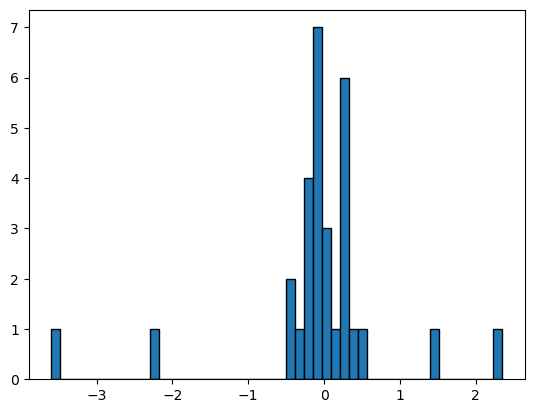

```python
plt.hist(log_nord_verao, bins=50, edgecolor='black')
```

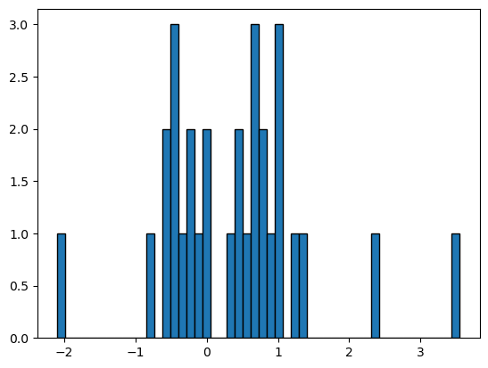

```python
plt.hist(log_sul_verao, bins=50, edgecolor='black')
```

De acordo com o teste de Shapiro-Wilk e considerando o nível de significância de 0.05, a distribuição de crescimentos em log na região Nordeste não segue uma distribuição normal. Desta forma será utilizado o método bootstrap que não precede de nenhuma distribuição nos dados.

**Critério de decisão:**

Se $\overline x_N$ for significamente maior que $\overline x_S$, $H_0$ será rejeitada. Ou seja, se a probabilidade de observar valores maiores que $\overline x_N - \overline x_S$ é suficientemente baixa (0.05 ou menos), $H_0$ vai ser rejeitada.

**Teste bootstrap:**

```python
diferenca_observada = media_nord - media_sul

def bootstrap(amostra_1, amostra_2, n_repeticoes):
    count = 0
    n_1 = len(amostra_1)
    n_2 = len(amostra_2)
    amostra_concat = np.concatenate((amostra_1, amostra_2))
    diferencas_bootstrap = []

    for _ in range(n_repeticoes):
        amostra_1_bootstrap = np.random.choice(amostra_concat, size=n_1, replace=True)
        amostra_2_bootstrap = np.random.choice(amostra_concat, size=n_2, replace=True)
        diferenca_bootstrap = np.mean(amostra_1_bootstrap) - np.mean(amostra_2_bootstrap)
        diferencas_bootstrap.append(diferenca_bootstrap)
        #Valores mais extremos que a diferença observada
        if (diferenca_bootstrap >= diferenca_observada):
            count += 1

    return np.array(diferencas_bootstrap), count


n_repeticoes = 1000
diferencas_bootstrap, count = bootstrap(log_nord_verao, log_sul_verao, n_repeticoes)

p_valor = count / n_repeticoes

print(f"Diferença observada: {diferenca_observada}")
print(f"P-valor (unilateral): {p_valor}")

if p_valor < alpha:
    print("Rejeite H0.")
else:
    print("Não rejeite H0.")
```

```
Diferença observada: -0.4325254335060609
P-valor (unilateral): 0.955
Não rejeite H0.
```

**Interpretação:**

Já que o $p-valor > \alpha$ é possível concluir que a média de crescimento geometrico no Nordeste não é significamente maior que a da região Sul, pois se a média aritmética dos dados transformados em log é maior em uma amostra, então a média geometrica também é maior.

**Invertendo a ordem da hipótese alternativa, ou seja:**

$$ H_0: \mu_S = \mu_N \\ H_\alpha: \mu_S > \mu_N\\ $$

```python
n_repeticoes = 1000
diferenca_observada = media_sul - media_nord
diferencas_bootstrap, count = bootstrap(log_sul_verao, log_nord_verao, n_repeticoes)

p_valor = count / n_repeticoes

print(f"Diferença observada: {diferenca_observada}")
print(f"P-valor (unilateral): {p_valor}")

if p_valor < alpha:
    print("Rejeite H0.")
else:
    print("Não rejeite H0.")
```

```
Diferença observada: 0.4325254335060609
P-valor (unilateral): 0.045
Rejeite H0.
```

Desta forma, a média de crescimento geométrico da região Sul nos meses de verão é significamente maior que a da região Nordeste.

### Teste de hipótese para os meses de inverno

O segundo teste será das médias de crescimento em log das duas regiões nos meses de inverno.

**Hipótese:** $$ H_0: \mu_S = \mu_N \\ H_\alpha: \mu_S > \mu_N\\ $$

**Colete de dados:**

```python
media_nord = np.mean(log_nord_inverno)
media_nord
```

```
0.3963738424945034
```

```python
desvio_nord = np.std(log_nord_inverno)
desvio_nord
```

```
0.6084319056319093
```

```python
media_sul = np.mean(log_sul_inverno)
media_sul
```

```
0.029338074981703353
```

```python
desvio_sul = np.std(log_sul_inverno)
desvio_sul
```

```
0.5971204741923558
```

**Normalidade dos dados:**

```python
estatistica, p_valor = shapiro(log_nord_inverno)
p_valor
```

```
0.0054204510524868965
```

```python
estatistica, p_valor = shapiro(log_sul_inverno)
p_valor
```

```
0.49575453996658325
```

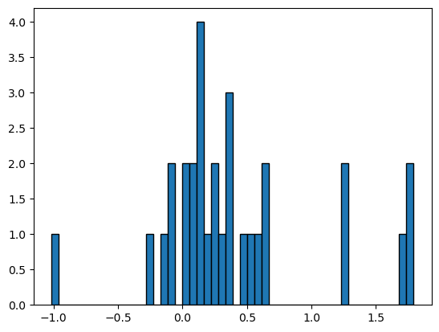

```python
plt.hist(log_nord_inverno, bins=50, edgecolor='black')
```

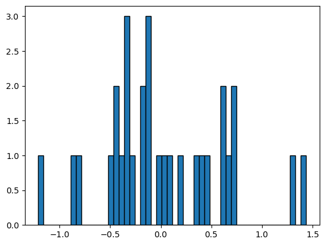

```python
plt.hist(log_sul_inverno, bins=50, edgecolor='black')
```

A distribuição de crescimentos em log na região Nordeste não segue uma distribuição normal. Portanto, o método bootstrap neste caso também será utilizado como teste.

**Critério de decisão:**

O mesmo do teste de hipótese anterior.

**Teste de hipótese:**

```python
n_repeticoes = 1000
diferenca_observada = media_sul - media_nord
diferencas_bootstrap, count = bootstrap(log_sul_inverno, log_nord_inverno, n_repeticoes)

p_valor = count / n_repeticoes

print(f"Diferença observada: {diferenca_observada}")
print(f"P-valor (unilateral): {p_valor}")

if p_valor < alpha:
    print("Rejeite H0.")
else:
    print("Não rejeite H0.")
```

```
Diferença observada: -0.36703576751280004
P-valor (unilateral): 0.984
Não rejeite H0.
```

**Interpretação:**

Já que o $p-valor > \alpha$ é possível concluir que a média de crescimento geometrico no Sul não é significamente maior que a da região Nordeste.

**Para a Hipótese considerando a mesma época:** $$ H_0: \mu_N = \mu_S \\ H_\alpha: \mu_N > \mu_S\\ $$

**Tem-se que:**

```python
n_repeticoes = 1000
diferenca_observada = media_nord - media_sul
diferencas_bootstrap, count = bootstrap(log_nord_inverno, log_sul_inverno, n_repeticoes)

p_valor = count / n_repeticoes

print(f"Diferença observada: {diferenca_observada}")
print(f"P-valor (unilateral): {p_valor}")

if p_valor < alpha:
    print("Rejeite H0.")
else:
    print("Não rejeite H0.")
```

```
Diferença observada: 0.36703576751280004
P-valor (unilateral): 0.016
Rejeite H0.
```

Ou seja, a média de crescimento geométrico da região Nordeste nos meses de inverno é significamente maior que a da região Sul.

## Referências

Saputra, P. M. A. (2023). COVID-19 and tourism industry: An investigation of spatial dependence in Europe. Cogent Social Sciences, 9(2).

Brida, J. G., Cortes-Jimenez, I., & Pulina, M. (2014). Has the tourism-led growth hypothesis been validated? A literature review.

Balaguer, J., & Cantavella-Jordá, M. (2002). Tourism as a long-run economic growth factor: The Spanish case. Applied Economics, 877–884.

ROGERSON, Christian M.; ROGERSON, Jayne M. COVID-19 and changing tourism demand: Research review and policy implications for South Africa. **African Journal of Hospitality, Tourism and Leisure**, v. 10, n. 1, p. 1-21, 2021.

Tsun, A. "Probability & statistics with applications to computing." (2020).

https://www.datacamp.com/pt/tutorial/geometric-mean

Horowitz, Joel L. "The bootstrap." Handbook of econometrics. Vol. 5. Elsevier, 2001. 3159-3228.

http://sillasgonzaga.com/material/curso_series_temporais/arima#estacionariedade-diferenciacao-e-autocorrelacao

https://www.machinelearningplus.com/machine-learning/how-to-detect-outliers-with-z-score/

https://ivanildo-batista13.medium.com/autoarima-em-python-26303d650de3

https://sigmoidal.ai/metricas-de-avaliacao-em-modelos-de-regressao-em-machine-learning/

https://www.datageeks.com.br/lstm/